# Lab 07 - Modelling course evaluations

Hannah Teasdale

2023-11-10

### Packages and Data

```r
library(tidyverse)
library(tidymodels)
```

```r
evals<-read.csv("data/evals.csv", row.names=1)
```

# Exercise 1: Exploratory Data Analysis

1. Visualize the distribution of `score` in the dataframe `evals`.

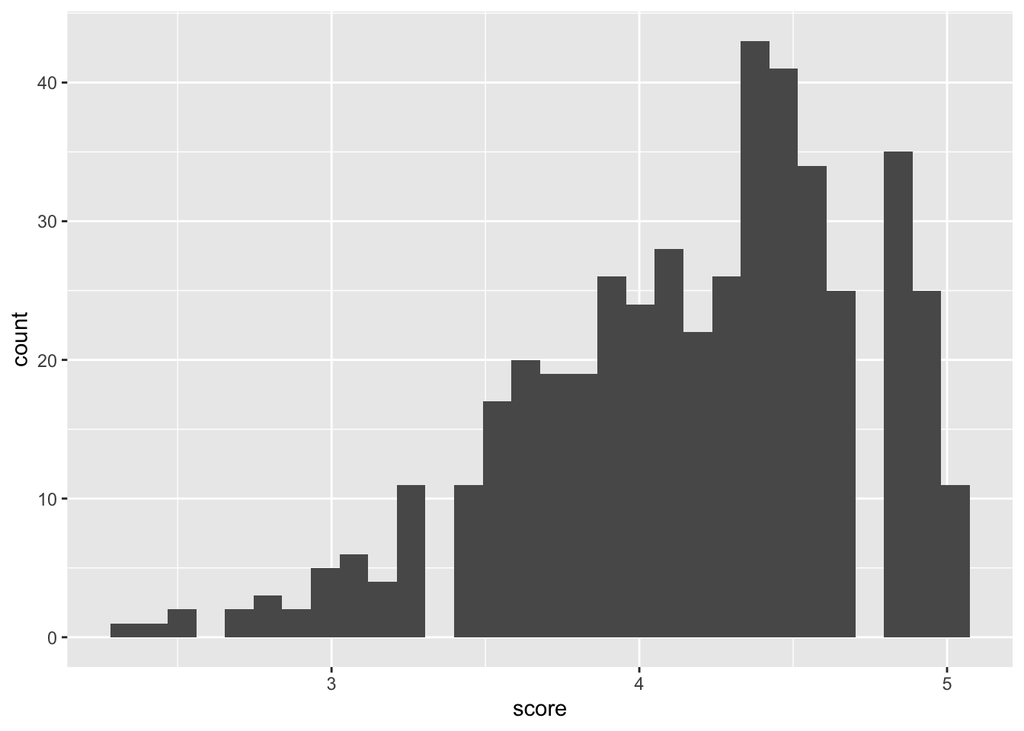

```r
# Ex1.1
ggplot(evals, mapping = aes(x = score, )) +
  geom_histogram(bins = 30)
```

```r
summarise(evals,
          mean_score = mean(score),
          med_score = median(score))
```

```
##   mean_score med_score
## 1    4.17473       4.3
```

Ex1.1 The data is left skewed,the mean is to the left of the median.

2. Visualize and describe the relationship between `score` and `bty_avg` using `geom_point()` to represent the data.

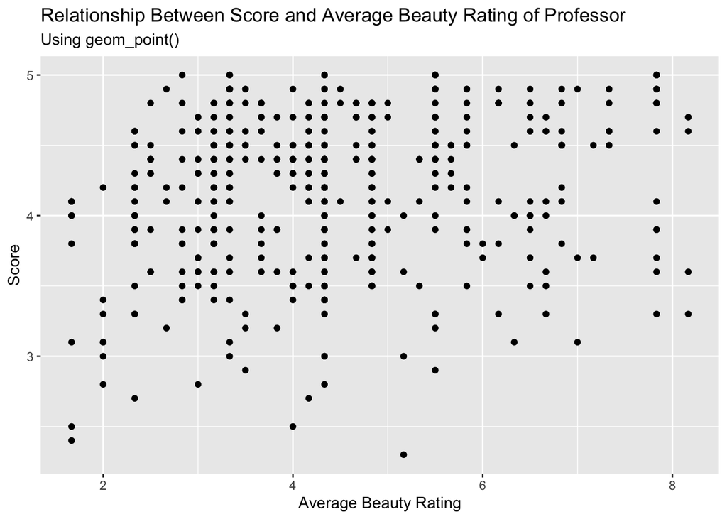

```r
#Ex1.2
ggplot(data = evals,
       mapping = aes(
         x = bty_avg,
         y = score
         )) +
  geom_point() +
  labs(
    x = "Average Beauty Rating",
    y = "Score",
    title = "Relationship Between Score and Average Beauty Rating of Professor",
    subtitle = "Using geom_point()" )
```

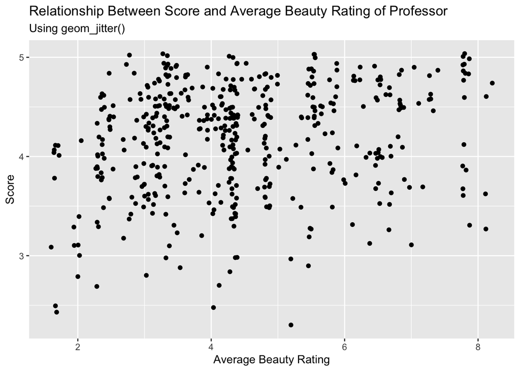

```r
ggplot(data = evals,
       mapping = aes(
         x = bty_avg,
         y = score
         )) +
  geom_jitter() +
  labs(
    x = "Average Beauty Rating",
    y = "Score",
    title = "Relationship Between Score and Average Beauty Rating of Professor",
    subtitle = "Using geom_jitter()" )
```

Ex1.2 geom_jitter() seems to be less rounded than geom_point().